# Predictive Analytics & Forecasting - Discussion 4

Eric Kenney

2023-07-24

## Data Set

For this weeks discussion I would like to examine a key theory in modern economics: the Phillips Curve. In short, the curve posits that there is a historical inverse relationship between the unemployment rate and the rate of inflation. From the Federal Reserve Economic Data (FRED) I have non-seasonally adjusted monthly data tracking the unemployment rate and the inflation rate in the United States. After importing and combining the data, using the unemployment rate as the response I will build an ETS model, an ARIMA model, and an ARIMA model using inflation as a predictor.

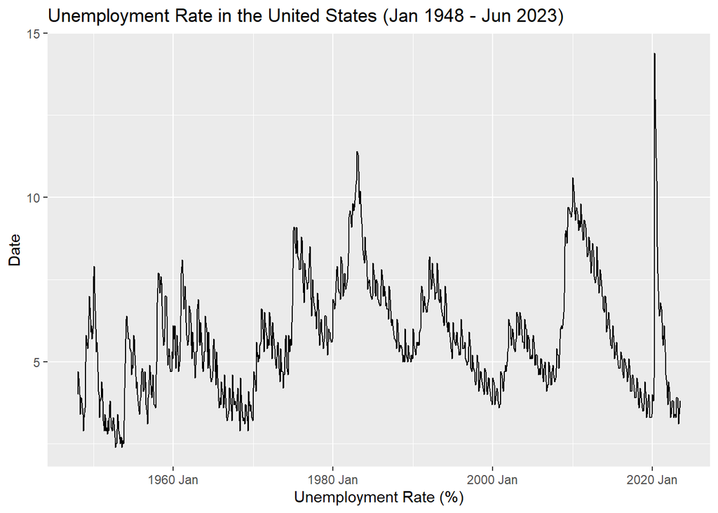

```r
unemployment = read.csv(file.path(path, "unemployment.csv"))
inflation = read.csv(file.path(path, "inflation.csv"))

unemployment = unemployment %>%
  rename("date" = "DATE", "unemployment" = "UNRATENSA") %>%
  mutate(date = yearmonth(date)) %>%
  as_tsibble(index = date)

inflation = inflation %>%
  rename("date" = "DATE", "CPI" = "CPALTT01USM657N") %>%
  mutate(date = yearmonth(date)) %>%
  as_tsibble(index = date)

unemployment %>%
  autoplot() +
  labs(x = "Unemployment Rate (%)", y = "Date",
       title = "Unemployment Rate in the United States (Jan 1948 - Jun 2023)")
```

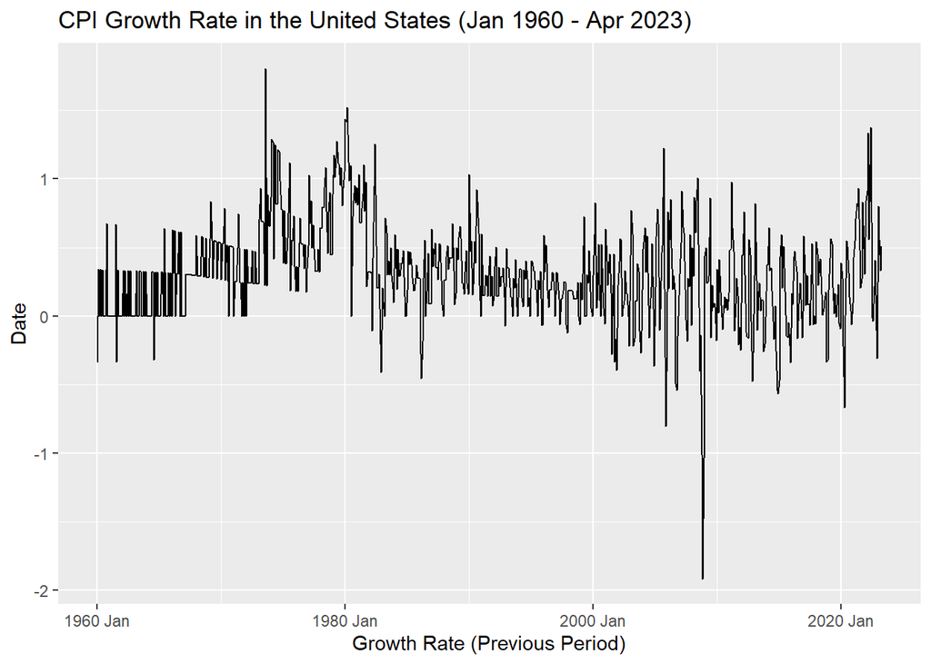

```r
inflation %>%
  autoplot() +
  labs(x = "Growth Rate (Previous Period)", y = "Date",
       title = "CPI Growth Rate in the United States (Jan 1960 - Apr 2023)")
```

```r
unemployment = unemployment %>%
  filter(as.Date(date) >= "1960-01-01" & as.Date(date) <= "2023-04-01")

unemployment_data = left_join(unemployment, inflation, by = "date")

unemployment_data = unemployment_data %>%
  mutate(CPI_lag = lag(CPI, 12))

total_obs = dim(unemployment_data)[1]
test_obs = 12
train_obs = total_obs - test_obs

unemployment_train = head(unemployment_data, train_obs)
unemployment_test = tail(unemployment_data, test_obs)
```

## Models

Next, I’ll build the three models for the data.

### ETS

```r
ets_auto = unemployment_train %>%
  model(ETS(unemployment))

report(ets_auto)
```

```
## Series: unemployment
## Model: ETS(A,N,A)
##   Smoothing parameters:
##     alpha = 0.9429612
##     gamma = 0.05703857
##
##   Initial states:
##      l[0]       s[0]      s[-1]      s[-2]      s[-3]       s[-4]     s[-5]
##  6.141645 -0.4211261 -0.4527189 -0.5595575 -0.4011803 -0.07772568 0.1964996
##     s[-6]      s[-7]      s[-8]     s[-9]   s[-10]    s[-11]
##  0.546494 -0.4579948 -0.1686095 0.4926464 0.679709 0.6235638
##
##   sigma^2:  0.2154
##
##      AIC     AICc      BIC
## 3817.250 3817.906 3886.511
```

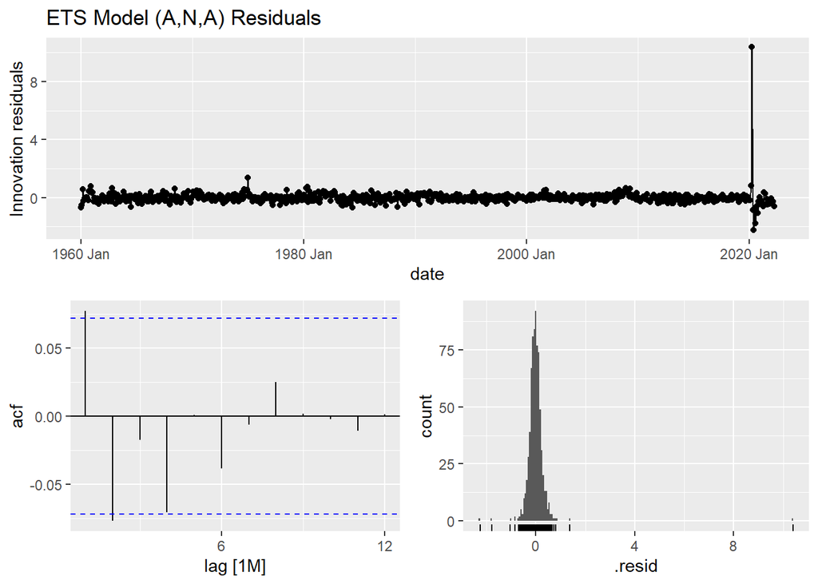

```r
ets_auto %>%
  gg_tsresiduals(lag_max = 12) +
  labs(title = "ETS Model (A,N,A) Residuals")
```

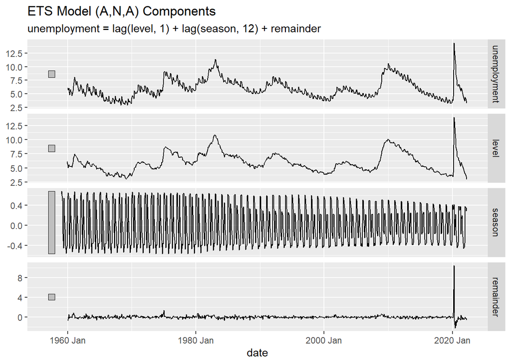

```r
components(ets_auto) %>%
  autoplot() +
  labs(title = "ETS Model (A,N,A) Components")
```

```r
augment(ets_auto) %>%
  features(.innov, ljung_box, lag = 12)
```

```
## # A tibble: 1 × 3
##   .model            lb_stat lb_pvalue
##   <chr>               <dbl>     <dbl>
## 1 ETS(unemployment)    14.5     0.267
```

The ETS residuals look normally distributed with the exception of one outlier. There is a lag spike, but a Ljung-Box test does not show any significance. The AIC is 3817.

### ARIMA

```r
arima_auto = unemployment_train %>%
  model(ARIMA(unemployment))

report(arima_auto)
```

```
## Series: unemployment
## Model: ARIMA(2,0,1)(2,0,0)[12] w/ mean
##
## Coefficients:
##          ar1     ar2     ma1    sar1    sar2  constant
##       0.0986  0.7770  0.9111  0.3208  0.2823    0.2822
## s.e.  0.0611  0.0592  0.0447  0.0363  0.0362    0.0331
##
## sigma^2 estimated as 0.2475:  log likelihood=-539.66
## AIC=1093.32   AICc=1093.47   BIC=1125.64
```

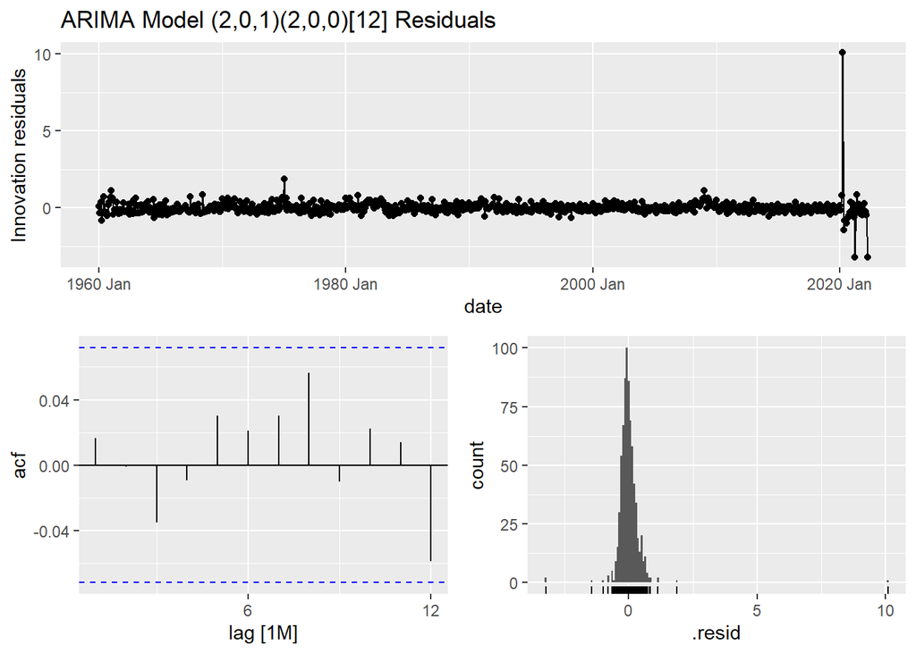

```r
arima_auto %>%
  gg_tsresiduals(lag_max = 12) +
  labs(title = "ARIMA Model (2,0,1)(2,0,0)[12] Residuals")
```

The ARIMA model performs better on this data set. The AIC is lower than the ETS model and there are no lag spikes with the residuals.

### ARIMA w/ Regressor

```r
arima_cpi = unemployment_train %>%
  model(ARIMA(unemployment ~ CPI_lag))

report(arima_cpi)
```

```
## Series: unemployment
## Model: LM w/ ARIMA(3,0,0)(2,0,0)[12] errors
##
## Coefficients:
##          ar1      ar2     ar3    sar1    sar2  CPI_lag  intercept
##       1.0113  -0.1355  0.0614  0.3046  0.2710   0.0706     5.8095
## s.e.  0.0380   0.0534  0.0380  0.0357  0.0371   0.0573     0.6579
##
## sigma^2 estimated as 0.2467:  log likelihood=-535.13
## AIC=1086.26   AICc=1086.45   BIC=1123.2
```

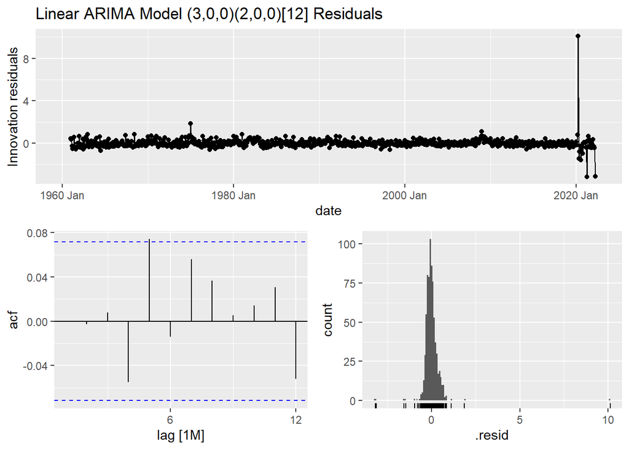

```r
arima_cpi %>%
  gg_tsresiduals(lag_max = 12) +
  labs(title = "Linear ARIMA Model (3,0,0)(2,0,0)[12] Residuals")
```

```r
augment(arima_cpi) %>%
  features(.innov, ljung_box, lag = 12)
```

```
## # A tibble: 1 × 3
##   .model                        lb_stat lb_pvalue
##   <chr>                           <dbl>     <dbl>
## 1 ARIMA(unemployment ~ CPI_lag)    12.7     0.388
```

The ARIMA model with the CPI predictor has a slightly lower AIC, suggesting a better fit. Like the previous ARIMA model there are no issues with residuals. Now, I will move onto testing.

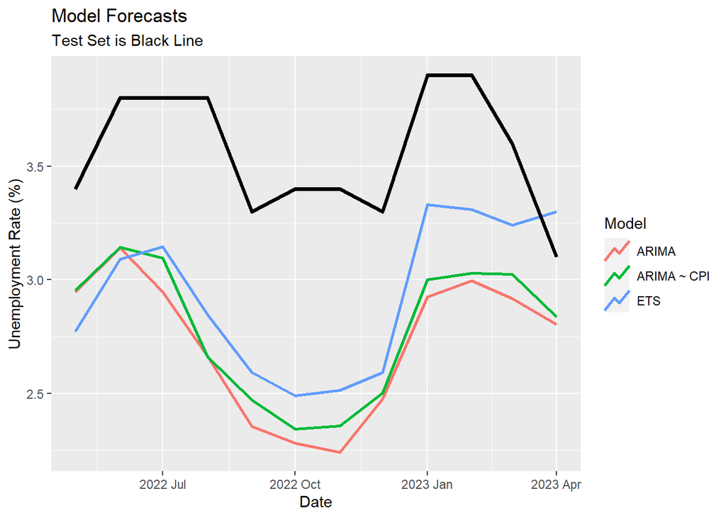

```r
unemployment_model = unemployment_train %>%
  model(`ETS` = ETS(unemployment),
        `ARIMA` = ARIMA(unemployment),
        `ARIMA ~ CPI` = ARIMA(unemployment ~ CPI_lag))

unemployment_forecast = unemployment_model %>%
  forecast(unemployment_test)

unemployment_forecast %>%
  autoplot(level = NULL, lwd = 1) +
  labs(x = "Date", y = "Unemployment Rate (%)",
       title = "Model Forecasts",
       subtitle = "Test Set is Black Line") +
  guides(color = guide_legend(title = "Model")) +
  geom_line(data = unemployment_test,
            aes(x = date, y = unemployment),
            lwd = 1.25)
```

```r
# Calculate accuracy
accuracy_table = unemployment_forecast %>%
  accuracy(unemployment_test) %>%
  select(-c(.type, MASE, RMSSE)) %>%
  rename("Model" = ".model")

kable(accuracy_table,
      format = "markdown",
      caption = "Model Accuracy")
```

Model Accuracy

| Model | ME | RMSE | MAE | MPE | MAPE | ACF1 |
| --- | --- | --- | --- | --- | --- | --- |
| ARIMA | 0.8341262 | 0.8733559 | 0.8341262 | 23.36756 | 23.36756 | 0.3762444 |
| ARIMA ~ CPI | 0.7735419 | 0.8125286 | 0.7735419 | 21.65431 | 21.65431 | 0.3197974 |
| ETS | 0.6224654 | 0.6881956 | 0.6557988 | 17.35487 | 18.43014 | 0.3728689 |

I only forecast 12 months since I had lagged the CPI predictor 12 months. We see each model follows the general trend of the data but appears to suffer from a negative bias.